# Practical session: Inferring demographic parameters from the site frequency spectrum (SFS)

Vitor C. Sousa

### Install required packages

To install it in R just use the command (within R or Rstudio)

```r
# install scrm package
install.packages("diagram")
install.packages("plotrix")

# Load the package
library("diagram")
library("plotrix")
```

# Objectives of this practical session

1. What is the SFS?
- Build the derived SFS from genotypic data
- Multi-dimensional SFS (2D-SFS)
2. Does the SFS contain information about demography?
- Infer parameters under simple models with fastsimcoal2 with simulated data
3. Application to real data from human populations (OPTIONAL)
- Apply fastsimcoal2 for a model with two populations
- Compare results with and without gene flow

## 1. What is the site frequency spectrum (SFS)?

The SFS (also called Allele frequency spectrum - AFS) is a summary of genome-wide data that describes the number of single nucleotide polymorphisms (SNPs) with a given derived allele frequency in our sample.

### 1.1. Multi-dimensional SFS (2D-SFS)

The SFS can be extended to any number of populations. For instance, if we had sampled data from two populations, the 2D-SFS corresponds to a matrix where the entry *(i,j)* corresponds to the count of genomic sites (SNPs) with a derived allele frequency of *i* in population 1, and frequency *j* in population 2.

Pop1

|  | snp1 | snp2 | snp3 | snp4 | snp5 | snp6 | snp7 | snp8 | snp9 | snp10 | snp11 | snp12 |
| --- | --- | --- | --- | --- | --- | --- | --- | --- | --- | --- | --- | --- |
| Pop1 ind1 | 1 | 0 | 0 | 0 | 0 | 0 | 1 | 0 | 0 | 1 | 0 | 1 |
| Pop1 ind2 | 0 | 2 | 0 | 1 | 0 | 0 | 0 | 0 | 0 | 0 | 1 | 0 |

Pop2

|  | snp1 | snp2 | snp3 | snp4 | snp5 | snp6 | snp7 | snp8 | snp9 | snp10 | snp11 | snp12 |
| --- | --- | --- | --- | --- | --- | --- | --- | --- | --- | --- | --- | --- |
| Pop2 ind1 | 0 | 0 | 0 | 0 | 0 | 1 | 0 | 1 | 1 | 0 | 0 | 1 |
| Pop2 ind2 | 0 | 1 | 0 | 0 | 0 | 0 | 1 | 0 | 1 | 1 | 0 | 1 |
| Pop2 ind3 | 1 | 0 | 0 | 0 | 0 | 0 | 0 | 0 | 0 | 1 | 2 | 2 |

> Exercise 1.1 (10 min).  
> Use a piece of paper and a pen to compute the observed 2 dimensional SFS from the above matrices with the genotypes for each population.

The 2D SFS can be seen as a matrix. Before starting answer the following questions:

- How many rows has the 2D SFS for this dataset? What determines the number of rows?
- How many columns has this 2D SFS for this dataset? What determines the number of columns?
- What is the range of possible values for each entry of the matrix?

First, you need to compute the absolute allele frequency for each SNP in each population.  
Second, you need to count the number of sites with a given allele frequency in each population.

#### Example of a 2D-SFS

The following matrix contains the 2D-SFS of 50,000 simulated sites from two populations, with a sample size of 2 diploids for pop1 and 3 diploids for pop2. Hence, we have 5 rows and 7 columns. Each entry *(i,j)* contains the number of SNPs with a derived allele frequency of *i* in pop1, and *j* in pop2. The sum of the entries in this matrix is the total number os sites, which in this case is 50,000.

|  | 0 | 1 | 2 | 3 | 4 | 5 | 6 |
| --- | --- | --- | --- | --- | --- | --- | --- |
| 0 | 23816 | 4606 | 1761 | 691 | 249 | 85 | 20 |
| 1 | 3425 | 2005 | 1355 | 890 | 489 | 228 | 103 |
| 2 | 839 | 877 | 874 | 805 | 599 | 432 | 225 |
| 3 | 188 | 350 | 444 | 553 | 571 | 506 | 436 |
| 4 | 37 | 68 | 160 | 248 | 407 | 599 | 1059 |

> Exercise 1.2 (5 min)  
> Based on the above matrix, answer the following questions.
- How many sites have 1 heterozygote individual in pop1 and 1 heterozygote individual in pop2?
- How many sites have a derived allele frequency of 4 in pop1 and a derived allele frequency of 4 in pop2?

## 2. Does the SFS contain information about demography?

### 2.1. Infer parameters under simple models with fastsimcoal2 with simulated data

We will analyse data simulated according to the following model.

[figure not shown]

#### 2.1.1. Input files: DATA

The input files with the observed SFS are in the folder: “Practical/FscInputFiles/”. Have a look at these files.

```r
# read the observed SFS
# 2D from two populations with different Ne that diverged some time ago
pop2d <- read.table("./FscInputFiles/2PopDiv20Mb_jointDAFpop1_0.obs", skip=1, stringsAsFactors = F, header=T, row.names = 1)
```

For the sample from two populations, the observed derived SFS is:

|  | d0_0 | d0_1 | d0_2 | d0_3 | d0_4 | d0_5 | d0_6 |
| --- | --- | --- | --- | --- | --- | --- | --- |
| d1_0 | 19969298 | 8235 | 2294 | 945 | 368 | 152 | 49 |
| d1_1 | 4188 | 1615 | 1142 | 703 | 471 | 234 | 112 |
| d1_2 | 1204 | 853 | 815 | 674 | 532 | 370 | 221 |
| d1_3 | 415 | 429 | 539 | 556 | 535 | 471 | 363 |
| d1_4 | 94 | 199 | 296 | 390 | 543 | 695 | 0 |

#### 2.1.2. Input files: DEFINITION OF MODELS

The model is defined in a TPL file, and the search range for the parameters are defined in the EST file.

#### 2.1.3 Settings to run fastsimcoal2

To run fastsimcoal2 we need to specify:  
- the number of coalescent simulations to approximate the expected SFS (-n and -N option). This should be larger than 100,000.  
- the number of optimization cycles (-l and -L option). This should be at least 20, but values between 50 and 100 are recommended.

### 2.2. Run fastsimcoal2 from R

The following scripts will run 1 fastsimcoal2 optimization, starting from a random initial starting value. When dealing with real data one needs to repeat at least 20-100 runs (i.e. runs with different initial starting values), selecting the run that maximizes the likelihood.

> Exercise 2  
> - Have a look at the observed SFS.  
> - Run fastsimcoal2 to estimate the parameters.  
> - Assess the fit of the expected SFS under the model to the observed SFS.

Run for the model with two populations. Have a look at the observed SFS file, at the TPL and EST files.

```r
# load functions to run fastsimcoal2 and to process the output
source("utilFscFunctions.r")
source("ParFileInterpreter-VS1.r")

# create a list that saves all the required settings to run fastsimcoal2
settings <- list()
# path to fastsicoal2 executable file
settings$pathToFsc <- "./fastsimcoal2/fsc_linux64/"
# path to input files (working directory)
settings$pathTo_InputFile <- "./FscInputFiles/"
# path to TPL and EST file (tags)
settings$TPL_EST_file_tag <- "2PopDiv20Mb"
# number of coalescent simulations
settings$n_coalsims <- 100000
# number of optimization cycles
settings$n_cycles <- 20

# run fastsimcoal2
#run_fsc2(settings)

# get the command line to run fastsimcoal2
cmd <- get_fsc2_commandline(settings)
cmd
```

```
## [1] "./fsc26  -t 2PopDiv20Mb.tpl -e 2PopDiv20Mb.est -L 20 -n 100000 -d -M -q -C1 -c2 -B2;"
```

```r
# STOP HERE!!!!
# You need to run this in a command line (cmd in Windows) or in a Unix terminal in Linux or Mac.

# Once you run it, you can read the results.
# read the file with the maximum likelihood estimates
maxlhoodEstimates <- read.table(paste(settings$pathTo_InputFile, "/",
                                      settings$TPL_EST_file_tag, "/",
                                      settings$TPL_EST_file_tag, ".bestlhoods",
                                      sep=""), header=T)
# look at the parameter estimates
maxlhoodEstimates
```

```
##   NPOP1 NPOP2 NANC TDIV MaxEstLhood MaxObsLhood
## 1 20336  5310 9861 1028   -137359.5   -137353.9
```

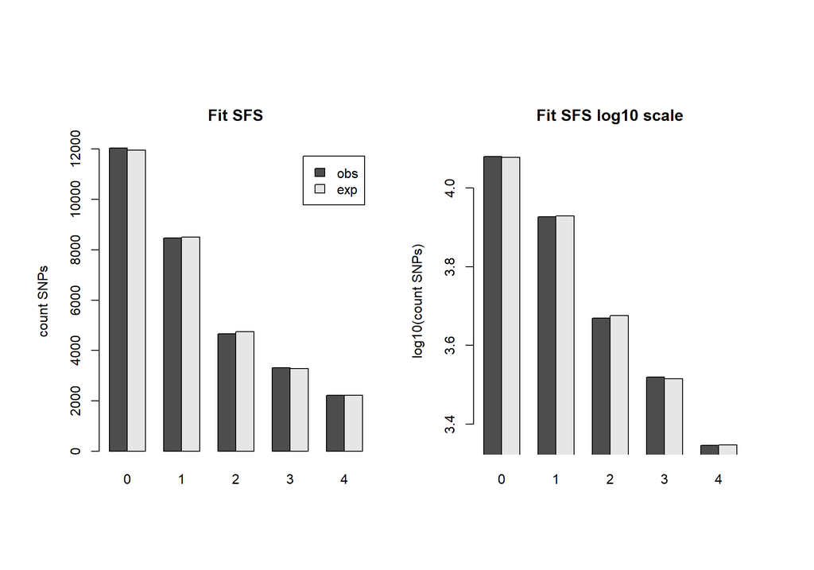

```r
# Read the observed SFS
obsfileend <- "_jointDAFpop1_0"
pop2d <- read.table(paste(settings$pathTo_InputFile,
                    settings$TPL_EST_file_tag, obsfileend, ".obs",
                    sep=""), skip=1, stringsAsFactors = F, header=T)
# Read the expected SFS
expectedSFS <- read.table(paste(settings$pathTo_InputFile,
                    settings$TPL_EST_file_tag, "/",
                    settings$TPL_EST_file_tag, obsfileend, ".txt",
                    sep=""), header=T)

# discard the monomorphic sites from the observed SFS
pol_obs_2d <- as.matrix(pop2d)
# observed SFS just with SNPs (polymorphic sites)
pol_obs_2d[c(1,1)] <- 0
# get the marginal 1d sfs for pop 1
marginal1d_sfs <- rowSums(pol_obs_2d)
exp.marginal1d_sfs <- rowSums(expectedSFS)
# Plot the observed vs expected SFS
plot_fitSFS_1d(marginal1d_sfs, exp.marginal1d_sfs, c(1,max(marginal1d_sfs)*1.1), "pop1")
```

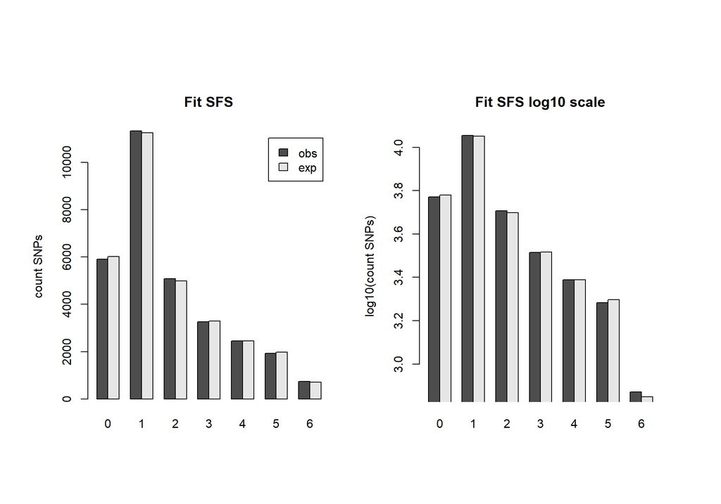

```r
# get the marginal 1d sfs for pop 2
marginal1d_sfs <- colSums(pol_obs_2d)
exp.marginal1d_sfs <- colSums(expectedSFS)
# Plot the observed vs expected SFS
plot_fitSFS_1d(marginal1d_sfs, exp.marginal1d_sfs, c(1,max(marginal1d_sfs)*1.1), "pop2")
```

> RESULTS of 1 run  
> What is the MaxObsLhood and the MaxEstLhood?

**MaxObsLhood**: is the maximum possible value for the likelihood if there was a perfect fit of the expected to the observed SFS, i.e. if the expected SFS was the relative observed SFS.  
**MaxEstLhood**: is the maximum likelihood estimated according to the model parameters.

The better the fit, the smaller the difference between **MaxObsLhood** and **MaxEstLhood**

> DISCUSSION  
> - Is the method able to infer the correct parameters?  
> - Does the expected SFS fit the observed SFS?

## 3. Application to real data from human population (OPTIONAL)

### 3.1. Apply fastsimcoal2 for a model with two populations

The folder “/Henn_et_al_data” contains exome data from two human populations (Namibian San, SAN; https://en.wikipedia.org/wiki/San_people, and Mexican Mayan, MAYA, https://en.wikipedia.org/wiki/Maya_peoples) published in Henn et al. (2015) PNAS (http://www.pnas.org/content/113/4/E440.abstract). This data was kindly provided by Stephan Peischl (http://www.bioinformatics.unibe.ch/about_us/staff/dr_peischl_stephan/index_eng.html), and cannot be used outside the scope of this course.

The folder “/Henn_et_al_data” contains the following files:  
- 2D-SFS for the two populations, assuming that we sequenced a total of 44Mb  
- Original genotypic matrix  
- TPL and EST files for a model without gene flow

> Exercise 3  
> 3.1. Infer the time of divergence between two human populations, San from Africa and Maya from America  
> - Start by considering a model without gene flow.  
> - Then, consider a model with gene flow.  
> What is the effect of adding gene flow into the model? What is the model that better fits the data?

```r
# load functions to run fastsimcoal2 and to process the output
source("utilFscFunctions.r")
source("ParFileInterpreter-VS1.r")

# create a list that saves all the required settings to run fastsimcoal2
settings <- list()
# path to fastsicoal2 executable file
settings$pathToFsc <- "./fastsimcoal2/fsc_linux64/"
# path to input files (working directory)
settings$pathTo_InputFile <- "./Henn_et_al_data/"
# path to TPL and EST file (tags)
settings$TPL_EST_file_tag <- "NoMig_San_Maya"
# number of coalescent simulations
settings$n_coalsims <- 100000
# number of optimization cycles
settings$n_cycles <- 20

# run fastsimcoal2
# run_fsc2(settings)

# get the command line to run fastsimcoal2
cmd <- get_fsc2_commandline(settings)
cmd
```

```
## [1] "./fsc26  -t NoMig_San_Maya.tpl -e NoMig_San_Maya.est -L 20 -n 100000 -d -M -q -C1 -c2 -B2;"
```

```r
# read the file with the maximum likelihood estimates
maxlhoodEstimates <- read.table(paste(settings$pathTo_InputFile, "/",
                                      settings$TPL_EST_file_tag, "/",
                                      settings$TPL_EST_file_tag, ".bestlhoods",
                                      sep=""), header=T)
# look at the parameter estimates
maxlhoodEstimates
```

```
##   NPOP1 NPOP2  NANC TDIV MaxEstLhood MaxObsLhood
## 1  7131 34893 18402 3802   -476864.3   -475819.9
```

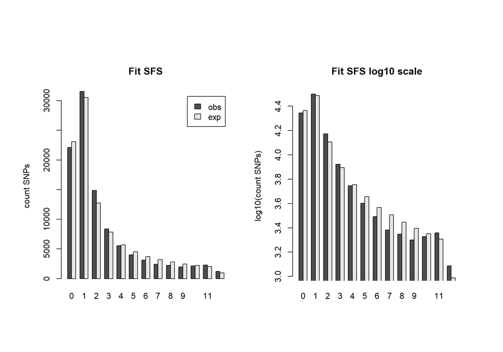

```r
# Read the observed SFS
obsfileend <- "_jointDAFpop1_0"
# 2D from two human populations: San and Maya
maya_san_2dsfs <- read.table(paste(settings$pathTo_InputFile, "/", settings$TPL_EST_file_tag, obsfileend,".obs",sep=""), skip=1, stringsAsFactors = F, header=T, row.names = 1)
# Read the expected SFS
expectedSFS <- read.table(paste(settings$pathTo_InputFile,
                    settings$TPL_EST_file_tag, "/",
                    settings$TPL_EST_file_tag, obsfileend, ".txt",
                    sep=""), header=T)

# discard the monomorphic sites from the observed SFS
pol_obs_2d <- as.matrix(maya_san_2dsfs)
# observed SFS just with SNPs (polymorphic sites)
pol_obs_2d[c(1,1)] <- 0
# get the marginal 1d sfs for pop 1
marginal1d_sfs <- rowSums(pol_obs_2d)
exp.marginal1d_sfs <- rowSums(expectedSFS)
# Plot the observed vs expected SFS
plot_fitSFS_1d(marginal1d_sfs, exp.marginal1d_sfs, c(1,max(marginal1d_sfs)*1.1), "San")
```

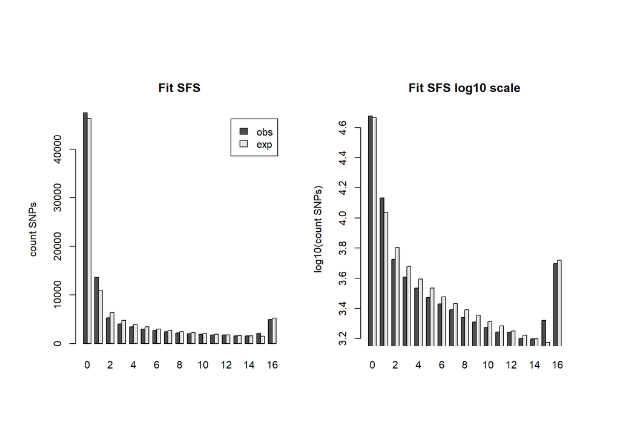

```r
# get the marginal 1d sfs for pop 2
marginal1d_sfs <- colSums(pol_obs_2d)
exp.marginal1d_sfs <- colSums(expectedSFS)
# Plot the observed vs expected SFS
plot_fitSFS_1d(marginal1d_sfs, exp.marginal1d_sfs, c(1,max(marginal1d_sfs)*1.1), "Maya")
```

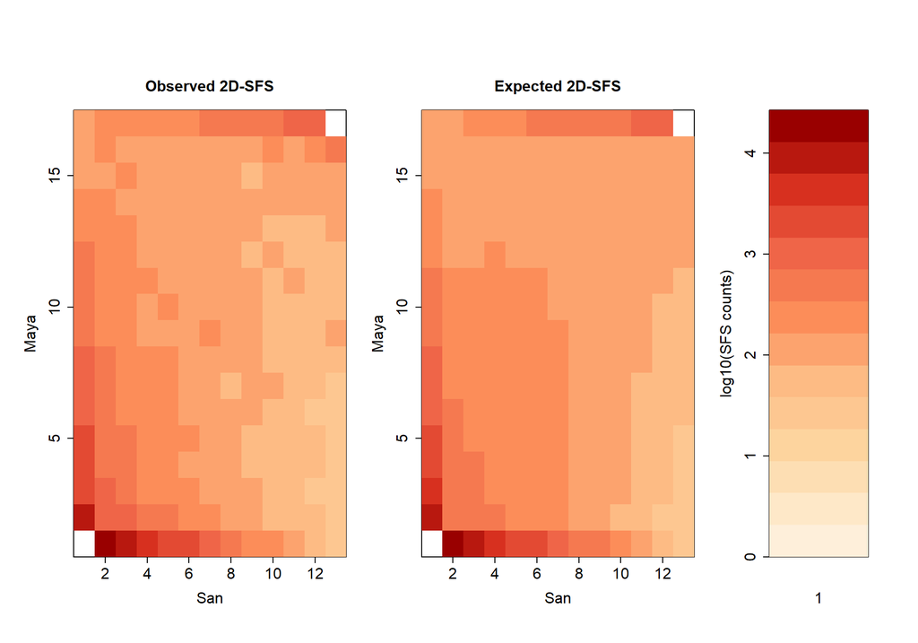

```r
# plot the fit of the 2D SFS
plot2dSFS(pol_obs_2d,expectedSFS,"San","Maya", 1)
```

```r
# Draw a scenario of the model parameter estimates assuming a generation time of 29 years
# pdf(file=paste(settings$TPL_EST_file_tag,"_model.pdf", sep=""), width=8, height=10)
# path to the maxL.par file that is a par file with the parameters that maximize the likelihodo
path_to_maxL_file <- paste(settings$pathTo_InputFile, settings$TPL_EST_file_tag, "/",settings$TPL_EST_file_tag, "_maxL", sep="")
parFileInterpreter(args=path_to_maxL_file, pop.names=c("Maya","San"), gentime=29, printPDF=FALSE)
```

```
## [1] "./Henn_et_al_data/NoMig_San_Maya/NoMig_San_Maya_maxL"
```

```r
# dev.off()
```

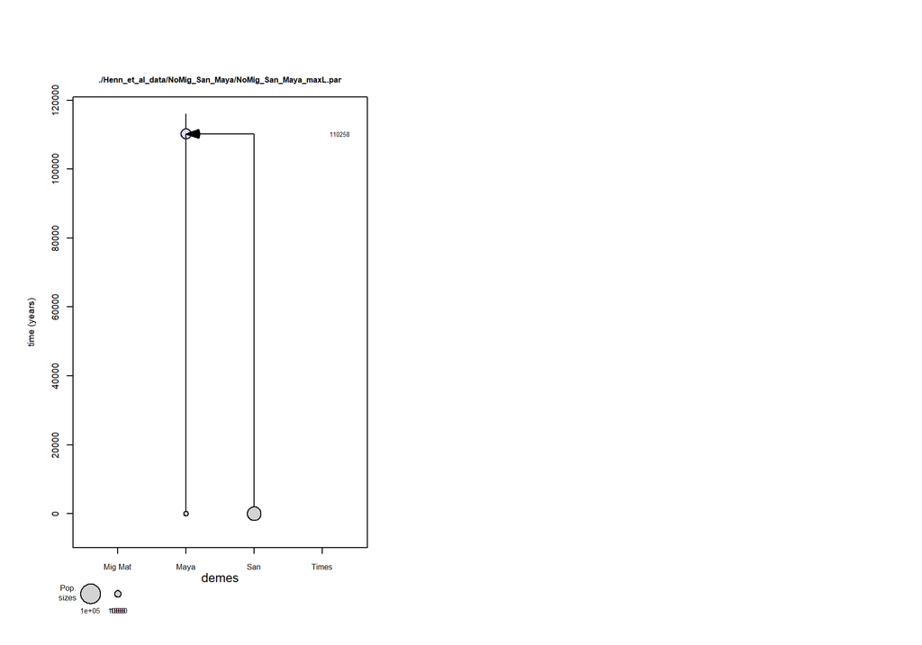

> DISCUSSION  
> - Does the expected SFS fit the observed SFS?  
> - How are the parameter values affected by adding migration? Would you change your conclusions?  
> - Is the model with migration better than a model without migration?  
> - Are these models sufficient to explain the data? Here we analyzed data from exome sequencing. Can we trust these demographic estimates?